# Scottish COVID Response Consortium (SCRC)

EERA model overview

Thibaud Porphyre, Mark Bronsvoort

EPIC, The Roslin Institute, University of Edinmburgh

Peter Fox, Kristian Zarębski, Qingfeng Xia, Sanket Gadgil

UKAEA

03/06/2020

## Project Details

Version:

## Model overview

### Model struture

Programming

- C++
- Tau-leap (Poisson process)
- Daily time step

Spatial scale

Flexible

Model type

Age-structured compartmental stochastic model

Features

- HCW considered as a separated population and treated as an additional age class for disease progression
- Different transmission behaviour between community and HCW
- Hospitalisation rate as a function of bed capacity

Mode

- Inference using ABC-smc
- Forward simulation

### Purpose

Short-term goals

- Inference of key epidemiological parameters
- Impact of scales (national vs regional vs health board) on parameter estimates

Medium-term goals

- Prediction of community level infection
- Optimization lifting movement restrictions strategies

## Model structure

### General disease progression

- Stochastic, compartmental SEI3HRD model.
- Flow description (see below):
- Exposed individuals (Ea) will become pre-clinically infectious (Ia). From there, a portion of infected individuals will develop to be asymptomatic while the remaining will be symptomatic (Isa)
- asymptomatic individuals will sstay infectious for relatively long period and will recover (Ra) following a gamma-distributed decay.
- Recovery, hospitalisation and death of symptomatic individuals is based on age and the number of bed available in COVID wards.
- A portion of symptomatic individuals will develop severe clinical symptoms based on age and will remain infectious (through self-isolating) for a gamma-distributed stay of mean $\theta_s$. If bed capacity is optimum (i.e. Ha/K ~ 0), all severe cases will be hospitalised (Ha). Otherwise (i.e. Ha/K ~ 1), all severe cases will remain at home where they will die (Da), undetected from hospital surveillance.
- Hospitalized individuals will either recover or die based on age

### Spatial structure

- No spatial structure

### Demography

- 7 age groups: Under 20, 20-29,03-39, 40-49, 50-59, 60-69, 70 over
- 1 extra group to include health care worker (HCW), assumed to have similar behaviour as people between 20 and 59 (i.e. mean behaviour).

### Movement

- No movement
- Contact structured informed thought Age-mixing matrices giving mean number of contacts per day between age groups.

### Main version

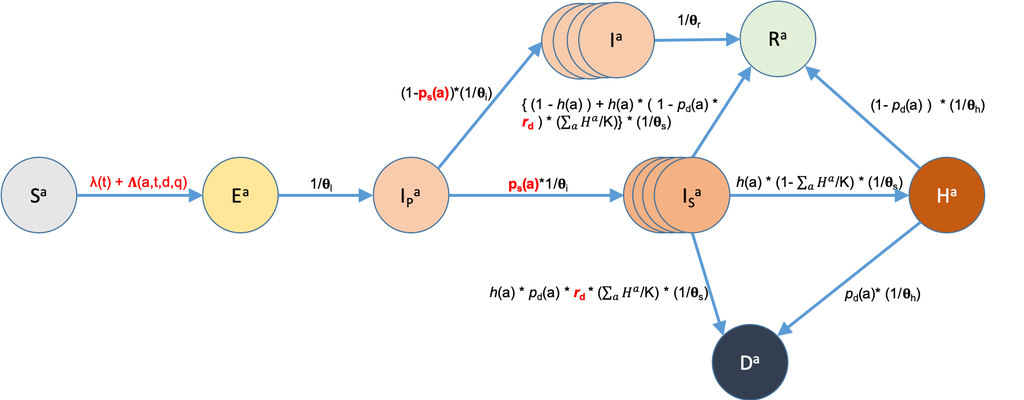

Figure 1: the original framework

### Alternative versions

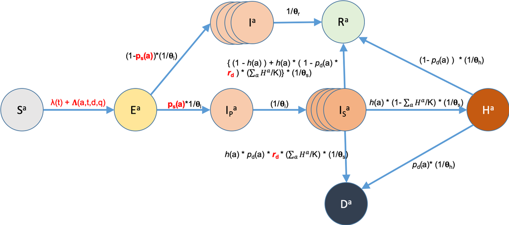

Figure 2a: the “irish” framework

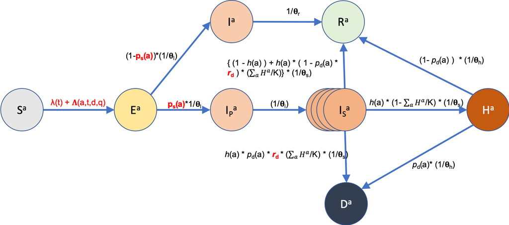

Figure 2b: the “irish2” framework

- Note! In figure 1 and figure 2a Both the asymptomatic ($I^a$) and symptomatic ($I_s^a$) compartments are divided into 4 successive compartments with exponential decay of rate=$4/\theta_r$ or $4/\theta_s$, respectively. As such, individuals remain in these states for a $gamma$-distributed stay of mean $\theta_r$ or $\theta_s$, respectively. In figure 2b, only symptomatic individuals will remain in the $I_s^a$ state for a $gamma$-distributed stay.

## Infectious process

### Community infection process

In the model, the virus can be transmitted from an infectious individual, either asymptomatic or symptomatic, to a susceptible individual of any age class $a$ at a rate $\Lambda(a,t)$, which depends on the number of daily contacts between individuals of age class $a$. Here, we define $c(a,j,t)$ the expected number of daily contacts of a single individual of age class $a$ with individuals of age class $j$. In the model, $c(a,j,t)$ will change as a function of the control measures implemented to mitigate the spread of the virus during the course of the outbreak. We further assumed that all symptomatic infectious individuals will self-isolate and will only contact $q$ individuals from their household. As such, $\Lambda(a,t)$ can be formulate such as:

$$\begin{aligned}
\Lambda\left ( a,t \right )=
\sum_{j\in \forall a}p_{i}.c(a,j,t).\frac{\left ( I_{p}^{j} + uI^{j} + q I_{s}^{j} \right )}{ N^{j}}.
\end{aligned}$$

where, $N^a$ is the total number of individuals in each age class $a$; $u$ is the relative infectivity of asymptomatic individuals; and $p_i$ is the probability that a susceptible individual becomes infected given that a contact with an infectious individual has occurred. Here, we assumed that this probability $p_i$ is constant for all age classes $a$ and that $p_i.c(a,j,t)$ is the transmission rate of the disease from $j$ to $a$.

- Based on this model, the basic reproductive number of COVID19 in the general population, $R_0$, denoting the average number of secondary infections generated by a typical infectious individual in a fully susceptible population, is computed as the absolute value of the dominant eigenvalue of the next generation matrix $G_{aj}$, where each element of $G_{aj}$ is defined for the original version of the model as:

$$\begin{aligned}
G_{aj}=p_i.c(a,j,t).(\theta_i+u(1-p_s ) \theta_r+qp_s \theta_s))
\end{aligned}$$
whereas,

$$\begin{aligned}
G_{aj}=p_i.c(a,j,t).(u(1-p_s ) \theta_r+p_s (\theta_i+q\theta_s))
\end{aligned}$$

for the alternative (“irish”) version.

### HCW infection process

While we assumed that the clinical outcome of a given case does not impact upon transmission dynamics in the general population, hospitalised individuals represent a source of infection for health care workers (HCW) exclusively. Concomitantly, we considered that HCW will acquire infection differently to the general population, through contact with hospitalised individuals only. Particularly, we assumed that HCW will be tested regularly and will self-isolate perfectly, hence they represent a negligible source of infection for susceptible individuals in the rest of population. In this situation, transmission would depends on the expected number of patient-to-HCW contact $c_{hcw}$ and the probability $p_{hcw}$ that a susceptible HCW becomes infected given that a contact with an hospitalised patient occurred. To account for the distinct transmission risk of HCW among the population, we considered HCW as a separate age class and extended $\Lambda(a,t)$ such as:

$$\begin{equation}
\Lambda\left ( a,t \right )=
p_{hcw}.c_{hcw}.\frac{\sum_{j\in \forall a}H^{j}}{N^{a}}, ~\mathrm{if} \, ~a=\text{HCW}.
\end{equation}$$

where, $H^{a}$ is the number of hospitalised individuals of age class $a$. Note that HCW are behaving markedly different from the rest of the population. As such, we considered that HCW are not involved in the calculation of $R_0$.

### Pre-lockdown imports

- We further considered that multiple incursions of COVID19 occurred in Scotland prior the implementation of the lock down rather than assuming that epidemics start with a single initially infected individual. We therefore extended the transmission rate of an infectious individual to a susceptible individual ${\Lambda}'(a,t)$, such as ${\Lambda}'(a,t) = \lambda(T) + \Lambda(a,t)$, where $\lambda(T)$ is a constant background transmission parameter within a given time period $T$. It is worth noting that $\lambda(T)$ ultimately measures the number of infection events that are independent of the second order effect throughout $T$, and estimates would strongly depend on the duration for which the system is observed. Here, we considered $T$ starting 34 days prior the detection of the index case and ending when lock-down mitigation activities have been implemented, thereby restricting movement within Scotland and with other regions of the UK. The 34-day period prior detection of the index case was chosen because (1) it largely encompasses the time COVID19 was assumed introduced in Scotland (end of January, early February), (2) remains small enough to avoid adverse effect on the estimates of $\lambda(T)$ and (3) avoid partial weekly data.
- In the original model, number of daily primary infection events were distributed homogeneously and randomly within the >20yo population within a high-risk period $T$ prior detection of the index case (i.e first detected case), whereas the “irish” model would consider that incursion can occur in all age class.
- In all situations, we assumed that no incursion can occur in the HCW population.

## Control activities:

- Control activities implemented through change in Age-mixing matrices.
- Particularly, we consider $M^N$, $M^L$, $M^H$ are the age mixing matrices during the pre-lockdown period (no change compared to normal activities), when both work and school are closed, and when only home contacts are considered, respectively.
- We also consider $M$ the *waifw* (‘*who aquires infection from who*’) matrix used during similation, where each element of $M$ provides values of $c(a,j,t)$.
- We assumed that $c(a,j,t)$ would be markedly be reduced once social distancing measures have been implemented and enforced (“lock-down”), which include school closure and non-essential work. Once the lock-down has been enforced, efficacy of social distancing measures will further depend on compliance of individuals limiting their contact structure to home contact only. We therefore considered that a proportion $d$ of the population will chose to limit their contact to those from home only, while $1-d$ will contact their expected number of daily contact that are neither from work nor from school. Therefore:

$$M= (1-d)M^L + dM^H, \text{ when } t>t_{lockdown},\\
M= M^N, \text{ otherwise}$$

- If symptomatic, infectious individuals will self-isolate.
- Self-isolated individuals will only contact a *proportion* $q$ of the contacts they do at home, such as:

$$q= (1-\hat{q})\frac{1}{n^2}\sum_{a}\sum_{j} \frac{M^H(a,j)}{M(a,j)}$$
where $n$ is the number of age classes considered; and $\hat{q}$ the dampening factor of home contacts due to quarantine activities.

- Testing activities implemented by not yet active (extra epi states)

### Key assumptions:

- Symptomatic Infectious individuals will self-isolate.
- HCW will self-isolate perfectly once symptomatic.
- Number of HCW is proportional to population.
- Scots contact behaviour similar to the rest of the UK.

## Model parameters

[output not shown]

### age mixing matrices

- **source**: Prem et al (2017) https://doi.org/10.1371/journal.pcbi.1005697
- original data structure: age of individuals is categorised into 5-year age intervals: 0-4,5-9, 10-14,$\dots$,80+.
- age of individuals considered in the eeraCovid-model is categorised into ~10-year age intervals :
  - Under20,20-29, 30-39,$\dots$,70+.
  - pre-processing of contacts: mean estimates
- Note! Health care worker contact behaviour assumed similar to the average number of daily contacts of 20 to 59 yo individuals.
- **contact definition**: A contact was defined as either skin-to-skin contact such as a kiss or handshake (a physical contact), or a two-way conversation with three or more words in the physical presence of another person but no skin-to-skin contact (a nonphysical contact) ()

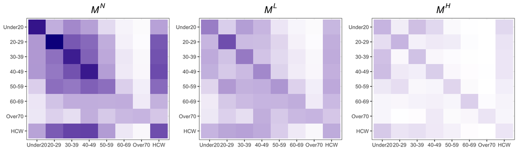

Figure 3: Mean number of daily contacts between individuals of given age classes carried out during the pre-lockdown period $M^N$, carried out at home and other places (but not at work nor school) $M^L$, or carried out at home only $M^H$

### age-structured parameters

- hospitalisation probability ($h(a)$) given symptoms extracted from https://www.ecdc.europa.eu/sites/default/files/documents/RRA-seventh-update-Outbreak-of-coronavirus-disease-COVID-19.pdf
- Note! Values were extracted graphically from figure. I have concern in their validity and exact estimates.
- Case fatality ratio ($cfr(a)$) from Russell et al (2020) https://www.eurosurveillance.org/content/10.2807/1560-7917.ES.2020.25.12.2000256.
- Note! values estimated from outbreak response in the Diamond Princess Cruise ship. General health, wealth and age structure of the study population is likely to not be representative to what observed in the UK. Also, due to limited number and physical restrictions in place, all individuals would have been tested, irrespective they were asymptomatic and symptomatic.
- probability of death given severe infection was computed as $p_d(a)=cfr(a)/h(a)$

Table 1: Age-strucutre parameters

| $a$ | $h(a)$ | $cfr(a)$ | $p_d(a)$ |
| --- | --- | --- | --- |
| Under20 | 0.143000 | 0.00100 | 0.0069930 |
| 20-29 | 0.114100 | 0.00200 | 0.0175285 |
| 30-39 | 0.117000 | 0.00200 | 0.0170940 |
| 40-49 | 0.102000 | 0.00400 | 0.0392157 |
| 50-59 | 0.125000 | 0.01300 | 0.1040000 |
| 60-69 | 0.200000 | 0.03600 | 0.1800000 |
| Over70 | 0.303000 | 0.11400 | 0.3762376 |
| HCW | 0.114525 | 0.00525 | 0.0458415 |

## Model inference

### Inference framework

- Model is integrated within an ABC-smc inference framework.
- Inference based on:
  - the daily reported incident cases, and
  - weekly reported number of deaths from hospital.
- Eligible particles were selected based on the normalised sum of squares of residuals. Specifically, we measured the deviation $D_k$ of each simulated trajectories $\hat{y}_k(t)$ constructed by each particle such as defined by:

$$D_k=\frac{1}{Y_k} \sqrt{\sum_{t=t_0}^{n}(y_k (t)-\hat{y}_k (t))^2 }$$

where $\hat{y}_k(t)$ and $y_k(t)$ denote the simulated and observed value on time step $t$ for the variable $k$ being predicted, respectively; and $Y_k$ is the total number of observations over the $n$ days of observation and for the given start date $t_0$. Here, $k$ are either the daily number of newly hospitalised individuals (aggregated over all age groups) or the weekly number of death events from hospitalised individuals (aggregated over all age groups).

### Key assumption for inference

- All reported cases are hospitalised (not yet testing)
- All regions of interest (e.g. Health Boards, regions, nations) are independent to each other (closed syst.)

### Parameters and priors

- Currently 8 parameters fitted: $\lambda$, $p_i$, $p_{hcw}$, $p_s(a>20yo)$, $c_{hcw}$, $\hat{q}$, $d$ and $r_d$
- Priors:
  - $\lambda$: uniform distribution ranging from 0.001 to 1 infection per million individuals at risk per day of exposure ($Unif(1e^{-9},1e^{-6})$).
  - $p_i$: Beta distribution with mean 0.25 ($Beta(3,9)$).
  - $p_s$: Beta distribution with mean 0.75 ($Beta(9,3)$).
  - $p_{hcw}$, $\hat{q}$ and $d$: Beta distribution with mean of 0.5 (Uninformative, $Beta(3,3)$).
  - $c_{hcw}$: Poisson distribution with mean of 42 contacts $Pois(42)$.
  - $r_d$: Gamma distribution of shape and scale of 1 (Uninformative, $\Gamma(1,1)$).

## Outputs

### Inference mode

3 files per smc step:

- <*output_abc-smc_particles*>: list of particles selected at each step, providing details on values of all statistics and particles’ weight
- <*output_abc-smc_simu*>: trajectories of both daily incident cases and weekly incident deaths for the selected particles
- <*output_abc-smc_ends*>: number of individuals per age group and per epidemiological states at the last day of the inference period.

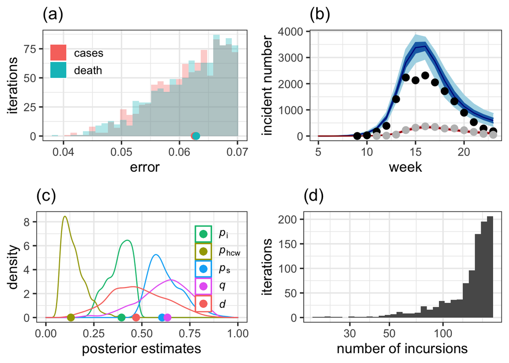

### Forward prediction mode

- <*output_forwardpred_simu*>: trajectories of both daily incident cases and weekly incident deaths
- <*output_forwardpred_epi*>: one file for each epidemiological state giving the number of individuals per age group and per day.

## Verification of the inference framework

```
##   iterID nsse_cases nsse_deaths    p_inf    p_hcw   c_hcw        d       q
## 1  10556  0.0563593   0.0664509 0.447205 0.157073 27.0452 0.577588 0.68222
##        p_s     rrd       intro
## 1 0.607802 1.53362 4.94759e-07
```

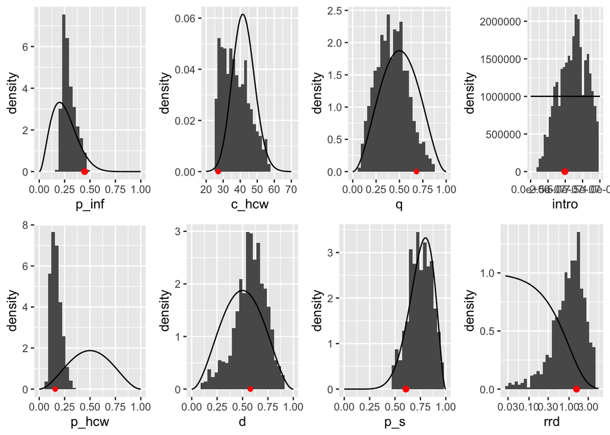

Figure 5: recapturing parameters. Dots: known parameters. Solid lines: priors.

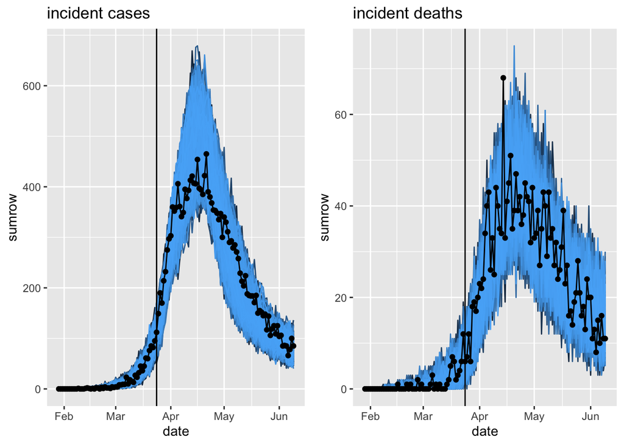

Figure 6: recapturing trajectories

## Impact of $u$ and $\theta_r$

### impact on trajectories

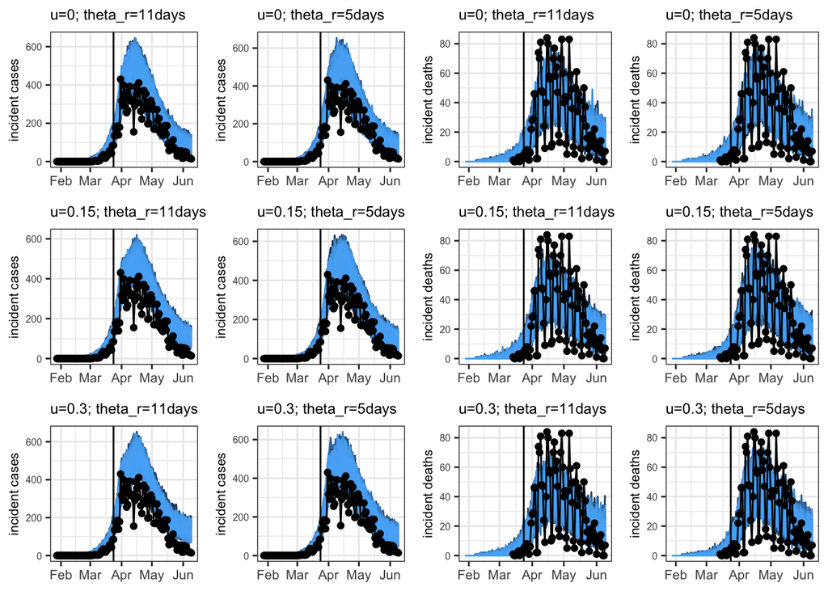

Figure 7: goodness of fit

### impact of parameters

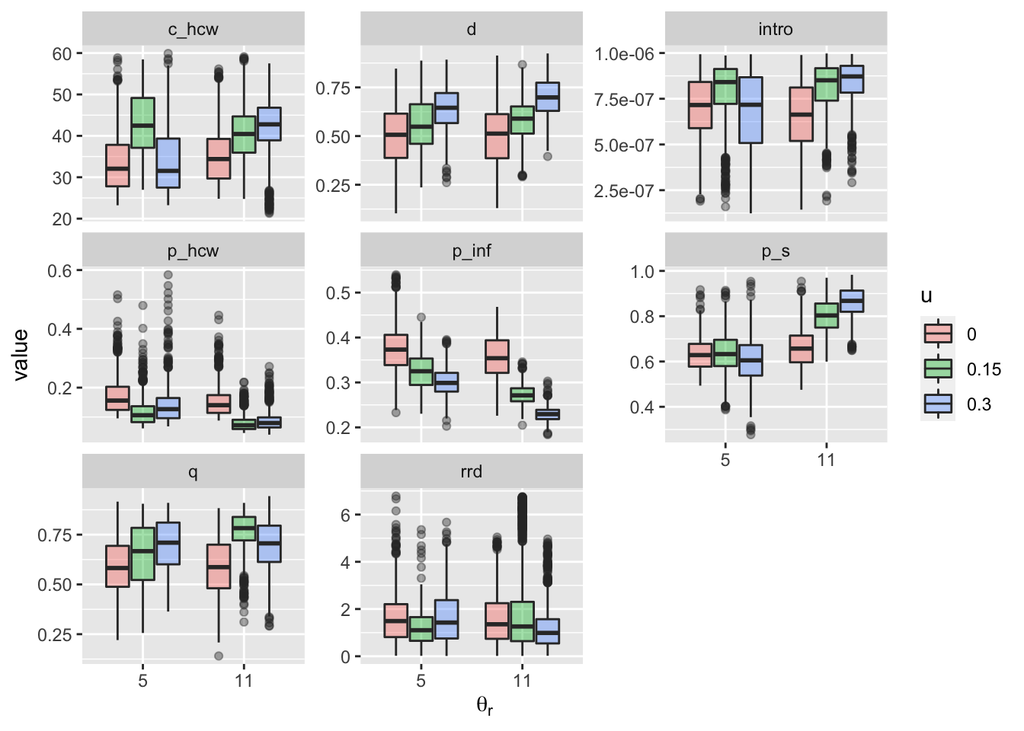

Figure 8: impact of $u$ and $theta_r$ on inferences

### impact on R0

estimated R_0 as function of u and theta_r

| u | theta_r | r_prelock | r_prelock_ci | r_lock | r_lock_ci |
| --- | --- | --- | --- | --- | --- |
| 0.00 | 11 | 2.045 | 1.842 - 2.264 | 0.871 | 0.806 - 0.924 |
| 0.15 | 11 | 2.253 | 1.961 - 2.587 | 0.870 | 0.82 - 0.925 |
| 0.30 | 11 | 2.389 | 2.122 - 2.835 | 0.920 | 0.867 - 0.977 |
| 0.00 | 5 | 2.050 | 1.842 - 2.297 | 0.875 | 0.808 - 0.926 |
| 0.15 | 5 | 2.196 | 1.979 - 2.466 | 0.878 | 0.813 - 0.927 |
| 0.30 | 5 | 2.407 | 2.078 - 2.809 | 0.881 | 0.819 - 0.937 |

[figure not shown]

Figure 9: impact of lockdown on $R_0$

## Cross validation

[to be done]

## Current targets for further development

Beyond development to enable cross validation and unitesting, I would like to:

- include testing/tracing and isolation via a compartment
- move away from a fixed (i.e. constant) point estimate of social distancing (i.e. $d$) by using the google mobility reports https://www.google.com/covid19/mobility/ to drive it.